# 议题

- "人工智能"能做什么？
- 怎么学习"人工智能"？
- 他是如何工作的?
- 几个简单的范例

人工智能？ 机器学习？ 深度学习？

[figure not shown]

机器学习是实现人工智能的一种方法，而深度学习是机器学习中的一种技术；

[figure not shown]

## 监督学习

[figure not shown]

从**有标记**的训练数据中推导出预测函数。有标记的训练数据是指每个训练实例都包括输入和期望的输出。简单的说，用我们**已经知道答案**的数据进行学习与训练；

在机器学习领域中，我们通常把输入称为`数据`，答案称为`标签`

[figure not shown]

对于监督学习，拥有多样化高质量的数据是最大的挑战

[figure not shown]

ImageNet有超过150万标注图像数据约2万多个分类

[figure not shown]

```python
%%HTML
<video width="600" height="400" controls> <source src="img/YOLOv3.mp4" type="video/mp4"></video>
```

[video not shown]

## 无监督学习

[figure not shown]

从**无标记**的训练数据中推断结论。用于发现隐藏的模式或者对数据进行分组。简单的说：给定数据，寻找隐藏的结构

### Word Embedding(词嵌入向量)

[figure not shown]

wiki:

猫，通常指家猫，在现代汉语中也昵称猫咪、咪咪、喵星人.......现在，`猫`成为世界上最为广泛的**宠物**之一

犬，现代俗称为狗，一种常见的犬科哺乳动物.............`狗`可用作陪伴、警用、军用、做**宠物**

[figure not shown]

### 万物皆可embedding

基于电商浏览记录、抖音视频观看记录、搜索记录构建上下文，并进行向量嵌入计算

[figure not shown]

## 对抗生成网络(GAN)

[figure not shown]

你能辨别出下图中哪些是真人哪些是GAN生成的照片吗？

[figure not shown]

## 强化学习

[figure not shown]

强化学习，强调让程序学习如何基于环境而行动，以取得最大化的预期利益。

电脑通过自我博弈学会了 补刀、勾兵、卡兵等操作

```python
%%HTML
<video width="600" height="400" controls> <source src="img/dota2.mp4" type="video/mp4"></video>
```

[video not shown]

# 机器学习的边界

机器学习目前三大方向

- 计算机视觉
- 语音识别
- 自然语言处理

谷歌语音助理

语音(输入)--> 文字 --> 对话模型 --> 文字 --> 语音(输出)

[figure not shown]

“推荐餐厅，不要日本菜！” 结果推荐的都是日本菜

[figure not shown]

[人工智障：你看到的AI与智能无关](https://mp.weixin.qq.com/s/tFcVohNjdhvBE_INQk9muQ)

今天还是1月6日，但2年前的今天，你与交往了5年的女友分手了，之后一直对她念念不忘，也没有交往新人。

你和往日一样，进电梯的，刚要关门的时候，匆忙进来的一个人，要关的门又打开了。就是你2年前分手的那位前女友。她进门时看到只有你们两，她抬头看了一下你，然后又低头找楼层电梯了：

> 这时她说：“你好”。

> 你也回答: “你好”。

[figure not shown]

> 你在想（圆柱）：一年多不见了，她还好么？

> 前女友在想（球）：这个人好眼熟，好像认识…

以下指代词具体指代了什么？

> A. “四川火锅比日料更好，因为**它**很辣”;

> B. “四川火锅比日料更好，因为**它**不辣”;

> C. 议员们拒绝给抗议者颁发许可证，因为**他们**害怕暴力

> D. 议员们拒绝给抗议者颁发许可证，因为**他们**提倡暴力

明文（含上下文）+ 场景模型（Context）+ 世界模型

# 怎样学习"人工智能"？

最重要的能力:

- 探索欲与耐心 ⋆⋆⋆⋆⋆
- 编程能力 ⋆⋆⋆
- 英语阅读能力 ⋆⋆⋆⋆
- 数学知识(线性代数、微积分、概率统计) +++

有用的工具/教材:

- 阅读别人的代码(Github/Kaggle) ⋆⋆⋆⋆
- 各类书籍与课程(数学之美/李宏毅深度学习/吴恩达机器学习) ⋆⋆⋆
- 一个好用的“梯子” ⋆⋆⋆⋆⋆
- colab ⋆⋆⋆⋆
- 四路泰坦 +++

以吴恩达深度学习为例:

- [deeplearning.ai - 主页 - 网易云课堂](https://study.163.com/provider/2001053000/index.htm)
- [github课程笔记](https://github.com/bighuang624/Andrew-Ng-Deep-Learning-notes)

视频 + 课程笔记 + 代码notebook

通过参与竞赛进行学习:

- [猫狗大战](https://www.kaggle.com/c/dogs-vs-cats-redux-kernels-edition)
- [查看别人的kernel](https://www.kaggle.com/jeffd23/catdognet-keras-convnet-starter)
- [知乎解析](https://zhuanlan.zhihu.com/p/51889181)

# 机器学习是如何工作的？

[figure not shown]

如何分开红点与蓝点？

[figure not shown]

通常我们称之为 损失函数(loss)

[figure not shown]

随机梯度下降

[figure not shown]

非线性问题

[figure not shown]

# "Hello World" in deep learning

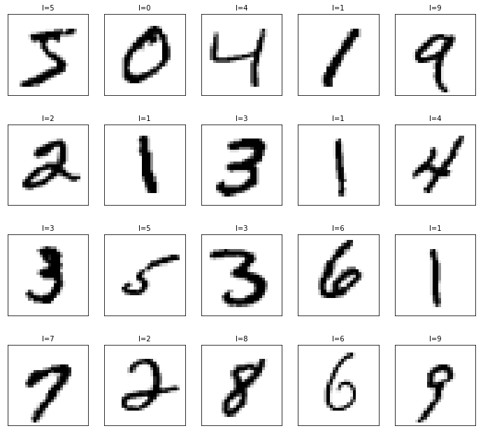

```python
plot_images_labels_predict(X_train_image, y_train_label, [], 0, 20)
```

[figure not shown]

## 第一步，构建网络（定义一批函数）

```python
import numpy as np
import pandas as pd
from keras.utils import np_utils  # 用來後續將 label 標籤轉為 one-hot-encoding

np.random.seed(10)
from keras.datasets import mnist

(X_train_image, y_train_label), (X_test_image, y_test_label) = mnist.load_data()

import matplotlib.pyplot as plt
def plot_image(image):
    fig = plt.gcf()
    fig.set_size_inches(2, 2)
    plt.imshow(image, cmap='binary') # cmap='binary' 參數設定以黑白灰階顯示
    plt.show()

def plot_images_labels_predict(images, labels, prediction, idx, num=10):
    fig = plt.gcf()
    fig.set_size_inches(12, 14)
    if num > 25: num = 25
    for i in range(0, num):
        ax=plt.subplot(5,5, 1+i)
        ax.imshow(images[idx], cmap='binary')
        title = "l=" + str(labels[idx])
        if len(prediction) > 0:
            title = "l={},p={}".format(str(labels[idx]), str(prediction[idx]))
        else:
            title = "l={}".format(str(labels[idx]))
        ax.set_title(title, fontsize=10)
        ax.set_xticks([]); ax.set_yticks([])
        idx+=1
    plt.show()

x_Train = X_train_image.reshape(60000, 28*28).astype('float32')
x_Test = X_test_image.reshape(10000, 28*28).astype('float32')
print("\t[Info] xTrain: %s" % (str(x_Train.shape)))
print("\t[Info] xTest: %s" % (str(x_Test.shape)))

# Normalization
x_Train_norm = x_Train/255
x_Test_norm = x_Test/255

y_TrainOneHot = np_utils.to_categorical(y_train_label) # 將 training 的 label 進行 one-hot encoding
y_TestOneHot = np_utils.to_categorical(y_test_label) # 將測試的 labels 進行 one-hot encoding

y_train_label[0] # 檢視 training labels 第一個 label 的值
y_TrainOneHot[:1] # 檢視第一個 label 在 one-hot encoding 後的結果, 會在第六個位置上為 1, 其他位置上為 0

from keras.models import Sequential
from keras.layers import Dense

import matplotlib.pyplot as plt
def show_train_history(train_history, train, validation):
    plt.plot(train_history.history[train])
    plt.plot(train_history.history[validation])
    plt.title('Train History')
    plt.ylabel(train)
    plt.xlabel('Epoch')
    plt.legend(['train', 'validation'], loc='upper left')
    plt.show()
```

```
	[Info] xTrain: (60000, 784)
	[Info] xTest: (10000, 784)
```

```python
model = Sequential()  # 定义一个新模型
model.add(Dense(units=256, input_dim=784, kernel_initializer='normal', activation='relu')) #定义一个256维的隐藏层
model.add(Dense(units=10, kernel_initializer='normal', activation='softmax')) # 定义一个10维的输出层
```

[figure not shown]

## 第二步，定义学习目标(衡量方法)

```python
model.compile(loss='categorical_crossentropy', optimizer='SGD', metrics=['accuracy'])
```

参数说明:

- **loss** : 使用 cross_entropy (Cross entropy) 交叉熵.

[figure not shown]

- **optimizer** : 随机梯度下降.
- **metrics** : 使用准确率进行评估

## 第三步，训练！（组合最合适的方程）

[figure not shown]

```python
train_history = model.fit(x=x_Train_norm, y=y_TrainOneHot, validation_split=0.2, epochs=10, batch_size=200, verbose=2)
```

```
Train on 48000 samples, validate on 12000 samples
 - 10s - loss: 1.7616 - acc: 0.5939 - val_loss: 1.2360 - val_acc: 0.7819
 - 1s - loss: 0.9825 - acc: 0.7996 - val_loss: 0.7536 - val_acc: 0.8397
 - 1s - loss: 0.6926 - acc: 0.8385 - val_loss: 0.5820 - val_acc: 0.8612
 - 1s - loss: 0.5707 - acc: 0.8586 - val_loss: 0.4971 - val_acc: 0.8764
 - 1s - loss: 0.5032 - acc: 0.8712 - val_loss: 0.4470 - val_acc: 0.8824
 - 1s - loss: 0.4600 - acc: 0.8787 - val_loss: 0.4140 - val_acc: 0.8890
 - 1s - loss: 0.4299 - acc: 0.8845 - val_loss: 0.3898 - val_acc: 0.8930
 - 1s - loss: 0.4073 - acc: 0.8895 - val_loss: 0.3720 - val_acc: 0.8967
 - 1s - loss: 0.3895 - acc: 0.8935 - val_loss: 0.3575 - val_acc: 0.9003
 - 1s - loss: 0.3750 - acc: 0.8968 - val_loss: 0.3462 - val_acc: 0.9036
```

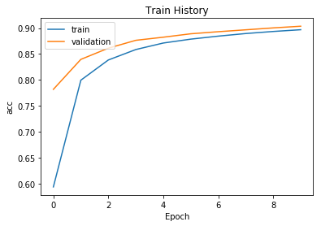

```python
show_train_history(train_history, 'acc', 'val_acc')
```

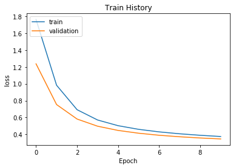

```python
show_train_history(train_history, 'loss', 'val_loss')
```

## 对结果进行测试

```python
scores = model.evaluate(x_Test_norm, y_TestOneHot)
print("\t[Info] Accuracy of testing data = {:2.1f}%".format(scores[1]*100.0))
```

```
	[Info] Accuracy of testing data = 90.5%
```

```
[5 8 8 4 2 6 0 6 4 2]
```

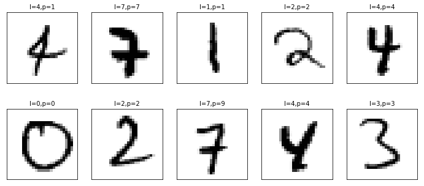

```python
prediction = model.predict_classes(x_Test_norm)  # Making prediction and save result to prediction
print("%s\n" % (prediction[240:250]))

plot_images_labels_predict(X_test_image, y_test_label, prediction, idx=300)
```